# Seagrass Site-level Production

Zach Monteith & Faye Manning

2023-03-09

## Seagrass Site-level Production Data Package

This script loads, cleans, and combines the datasets required for the Hakai Nearshore: Seagrass Site-level Production data package. All of these data are stored on the Hakai EIMS Data Portal.

**Notes for adding data:** When adding a new year’s worth of survey data, *do not replace the existing raw data files* in this data package with downloads for all years from the EIMS portal; rather, download *only* the new year’s raw data and *append* that to the existing raw data files. This is important because the existing raw data files have undergone a post-portal download QC and ongoing changes to the portal can/have created issues for those older years. The same thing should be done for retroactively adding missing data from previous years.

Bottom line: *always add to the existing raw data file rather than replace the whole file.*

### Setup

Clear work space prior to starting

```r
rm(list = ls())
```

Load necessary packages

```r
lapply(c("tidyverse",
         "lubridate",
         "magrittr",
         "DataCombine"),
       library,
       character.only = TRUE)
```

### Load and tidy data

Load data

```r
zmDensity <- read.csv("./raw-data/seagrass_density.csv")
zmHabitat <- read.csv("./raw-data/seagrass_habitat.csv")
names <- read.csv("./raw-data/divertender_names.csv")
sites <- read.csv("./raw-data/seagrass_sites.csv")
```

Tidy density column names

```r
zmDensity <-  rename_with(zmDensity, tolower)
colnames(zmDensity) <- gsub("\\.", "_", colnames(zmDensity))
names(zmDensity)[names(zmDensity) == "transect_dist__m_"] <- "transect_dist_m"
names(zmDensity)[names(zmDensity) == "canopy_height__cm_"] <- "canopy_height_cm"
zmDensity <- select(zmDensity, -c(action, comments))
colnames(zmDensity)
```

```
##  [1] "organization"     "work_area"        "project"          "survey"
##  [5] "site_id"          "date"             "sampling_bout"    "dive_supervisor"
##  [9] "surveyor"         "hakai_id"         "sample_type"      "depth"
## [13] "transect_dist_m"  "collected_start"  "collected_end"    "density"
## [17] "density__m2_"     "canopy_height_cm" "flowering_shoots" "quality_log"
```

Tidy habitat column names

```r
zmHabitat <-  rename_with(zmHabitat, tolower)
colnames(zmHabitat) <- gsub("\\.", "_", colnames(zmHabitat))
names(zmHabitat)[names(zmHabitat) == "transect_dist__m_"] <- "transect_dist_m"
zmHabitat <- select(zmHabitat, -c(action, comments))
colnames(zmHabitat)
```

```
##  [1] "organization"     "work_area"        "project"          "survey"
##  [5] "site_id"          "date"             "sampling_bout"    "dive_supervisor"
##  [9] "surveyor"         "hakai_id"         "sample_type"      "depth"
## [13] "transect_dist_m"  "collected_start"  "collected_end"    "bag_uid"
## [17] "bag_number"       "density_range"    "substrate"        "patchiness"
## [21] "adj_habitat_1"    "adj_habitat_2"    "sample_collected" "vegetation_1"
## [25] "vegetation_2"     "quality_log"
```

### Data QC

Before the data is ready to be packaged, this section will perform some basic quality control checks, ensuring all data is present and all values seem appropriate

#### Density surveys

Check all data are present:

- annual sites (Triquet, Goose, McMullin) have one set of data each year
- seasonal sites (Choked, Pruth, Koeye) have the same number of summer visits
- Choked and Pruth have February and November visits in 2017 and 2018, and a February visit in 2019
- secondary annual sites (McMullin S, Goose SE, Triquet N) only have 3 observations transects in 2018

Create a function for viewing number of observations at all sites, in a year, by month

```r
viewYearCounts <- function (data, year) {
  data %>%
    filter(year(date) == year) %>%
    ggplot(aes(x    = factor(transect_dist_m),
               fill = month(date))) +
    geom_histogram(stat = "count") +
    facet_grid(survey ~ factor(month(date))) +
    labs(title = year) +
    theme_classic()
}
```

Create a function for viewing all sites in a year, by month, for a given variable

```r
viewYearContinuous <- function (data, year, yVar, xVar = "survey") {
  data %>%
    filter(year(date) == year) %>%
    ggplot(aes_string(x = xVar,
                      y = yVar)) +
    geom_boxplot(outlier.colour = "red") +
    facet_grid(~ month(date)) +
    labs(title = year) +
    theme_classic() +
    theme(axis.text.x = element_text(angle = 45, hjust = 1))
}
```

Plot each year of data; check correct number of values are present

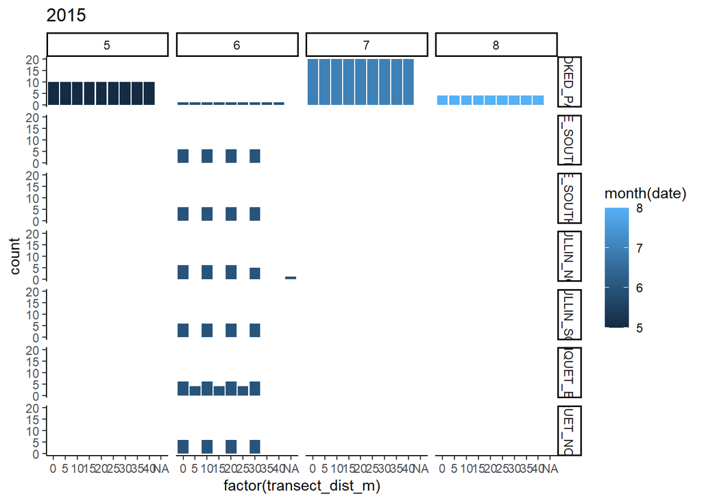

```r
viewYearCounts(zmDensity, "2015")
```

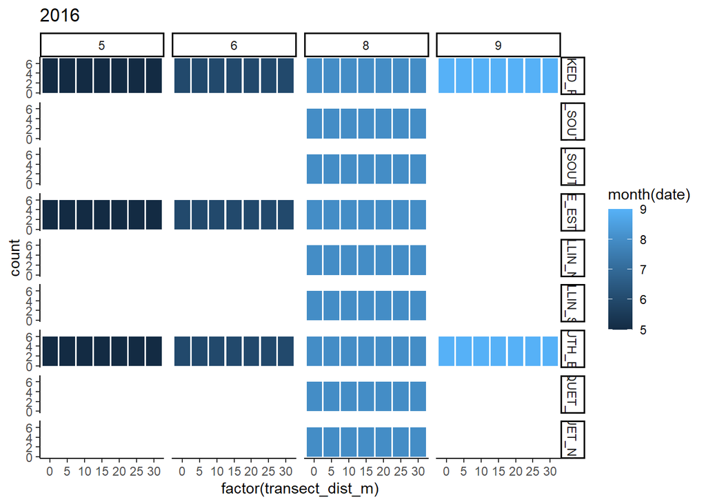

```r
viewYearCounts(zmDensity, "2016")
```

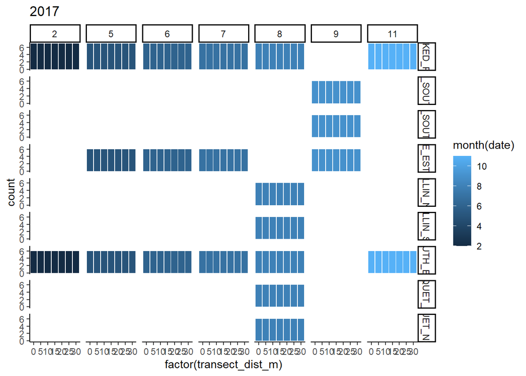

```r
viewYearCounts(zmDensity, "2017")
```

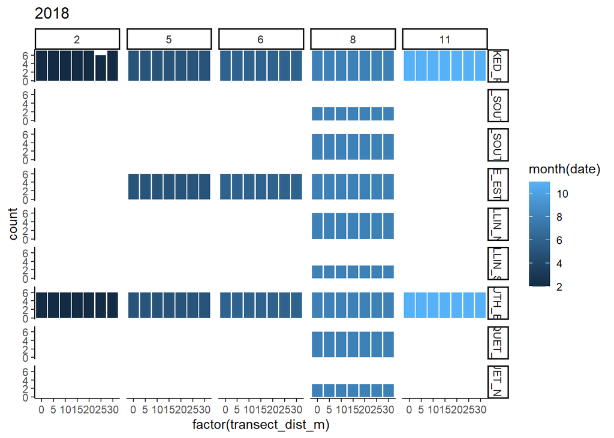

```r
viewYearCounts(zmDensity, "2018")
```

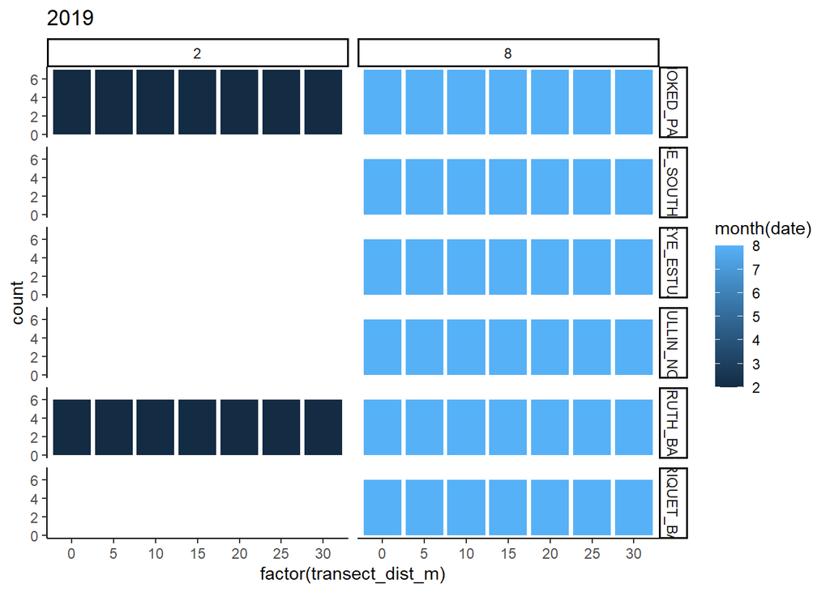

```r
viewYearCounts(zmDensity, "2019")
```

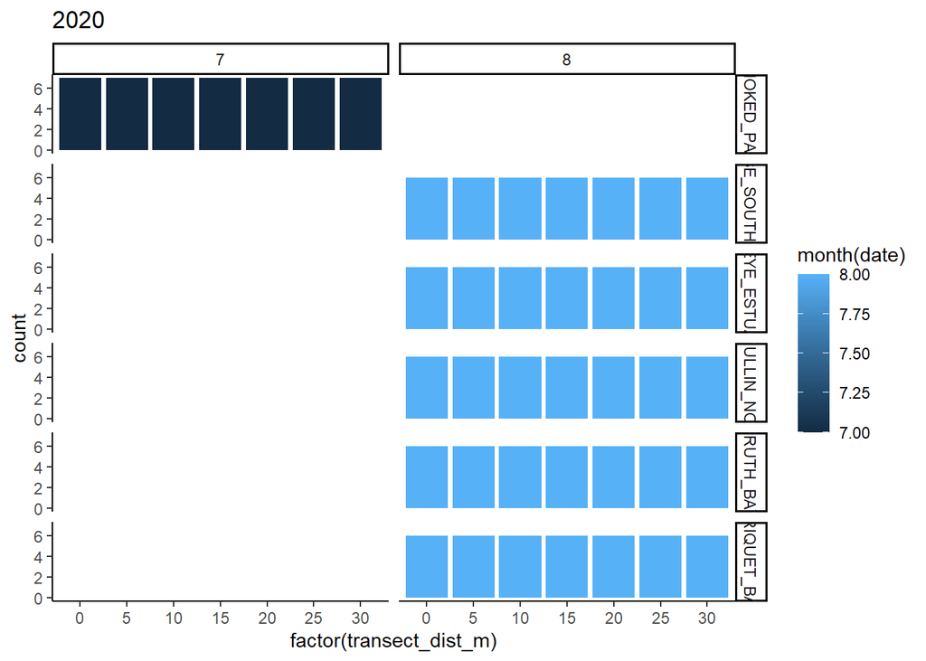

```r
viewYearCounts(zmDensity, "2020")
```

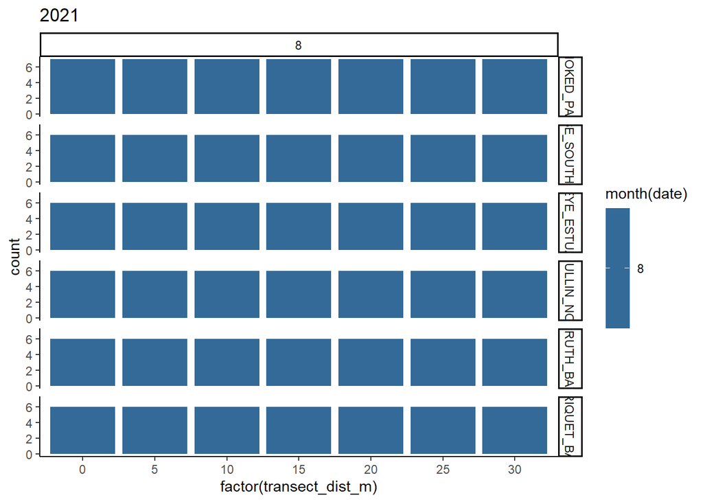

```r
viewYearCounts(zmDensity, "2021")
```

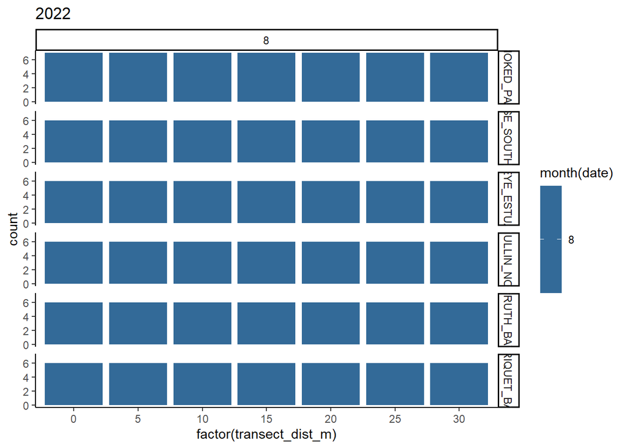

```r
viewYearCounts(zmDensity, "2022")
```

Plot each year of data; check for suspect values

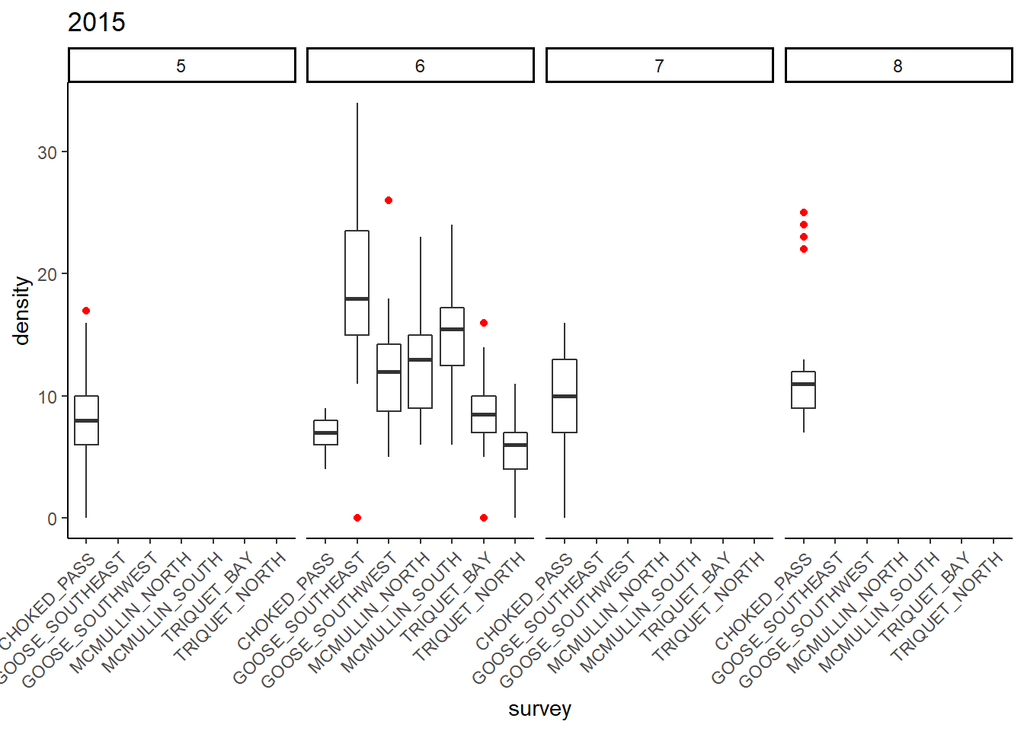

```r
viewYearContinuous(zmDensity, "2015", "density")
```

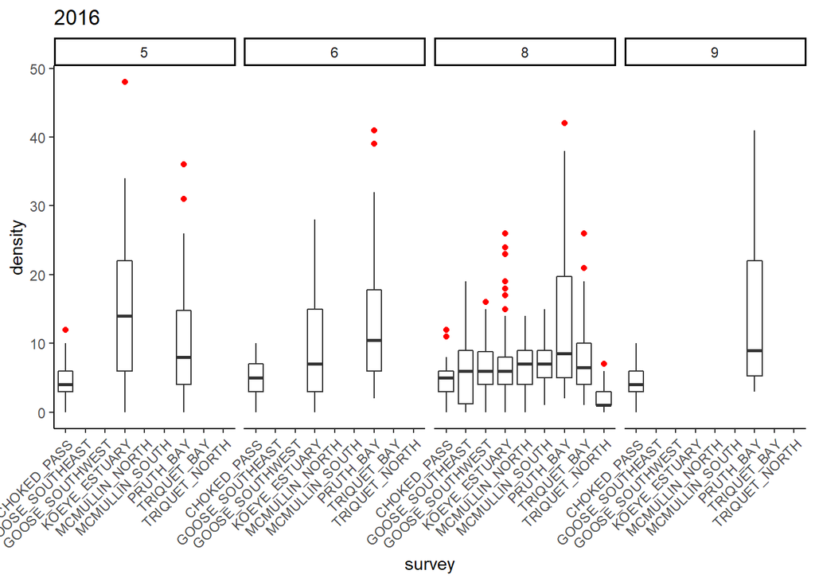

```r
viewYearContinuous(zmDensity, "2016", "density")
```

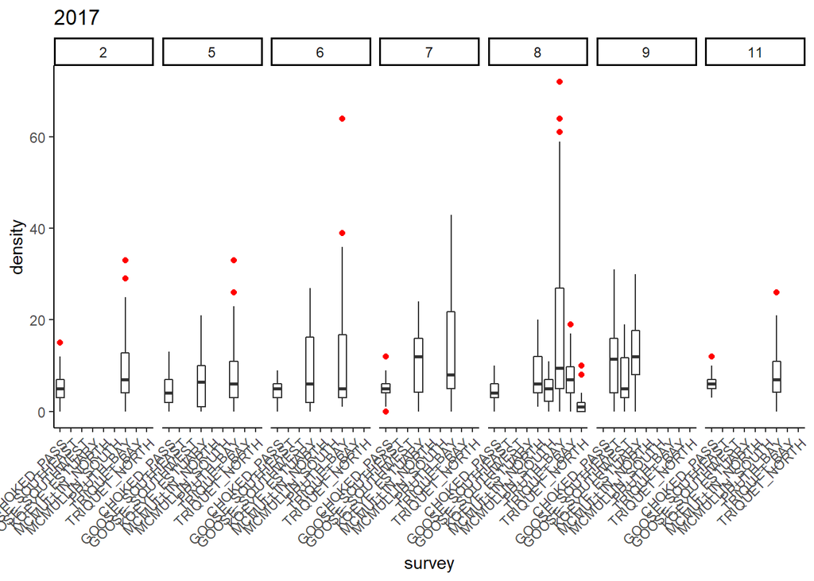

```r
viewYearContinuous(zmDensity, "2017", "density")
```

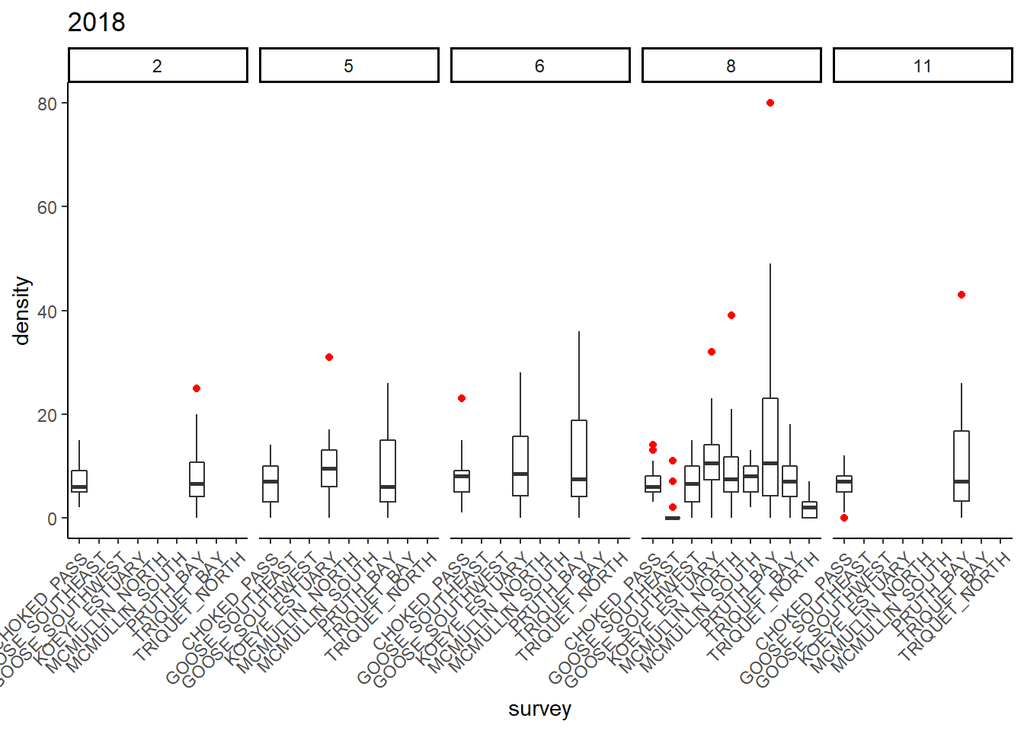

```r
viewYearContinuous(zmDensity, "2018", "density")
```

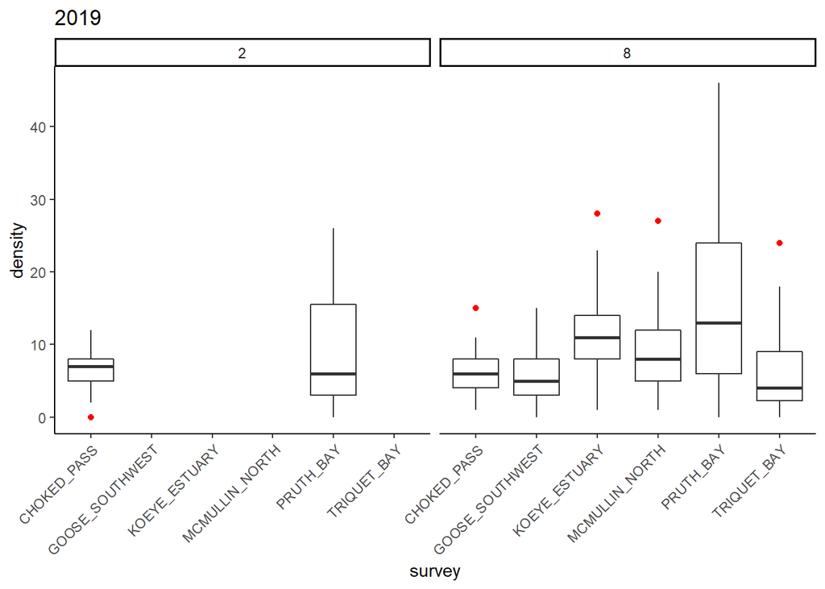

```r
viewYearContinuous(zmDensity, "2019", "density")
```

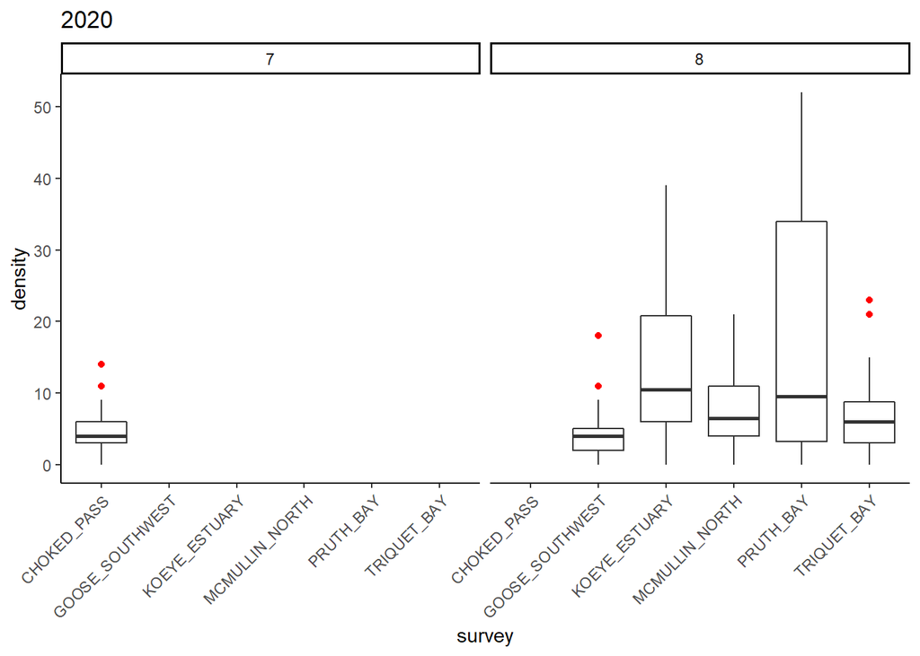

```r
viewYearContinuous(zmDensity, "2020", "density")
```

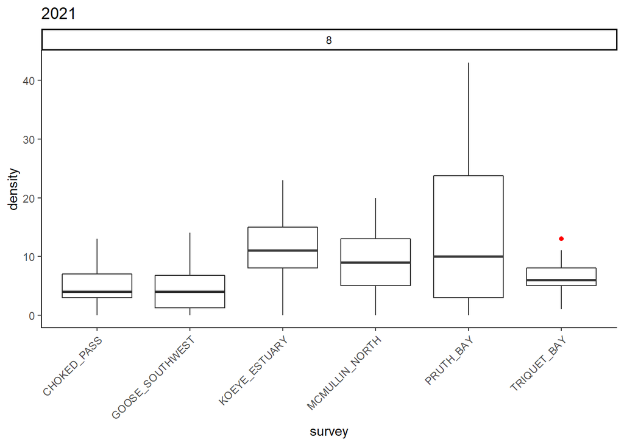

```r
viewYearContinuous(zmDensity, "2021", "density")
```

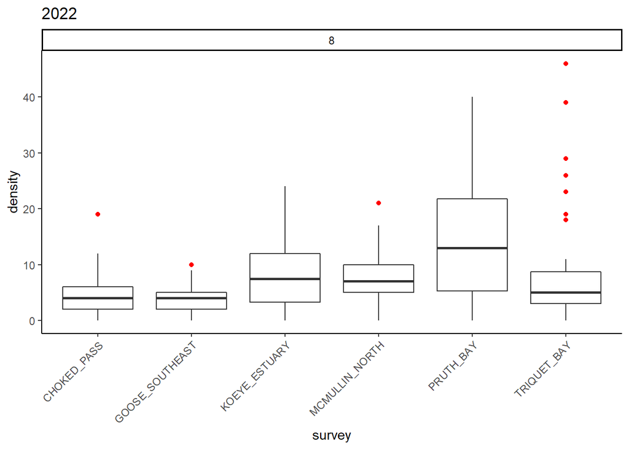

```r
viewYearContinuous(zmDensity, "2022", "density")
```

For suspect values (or number of observations), use the below chunk of code to “zoom in”

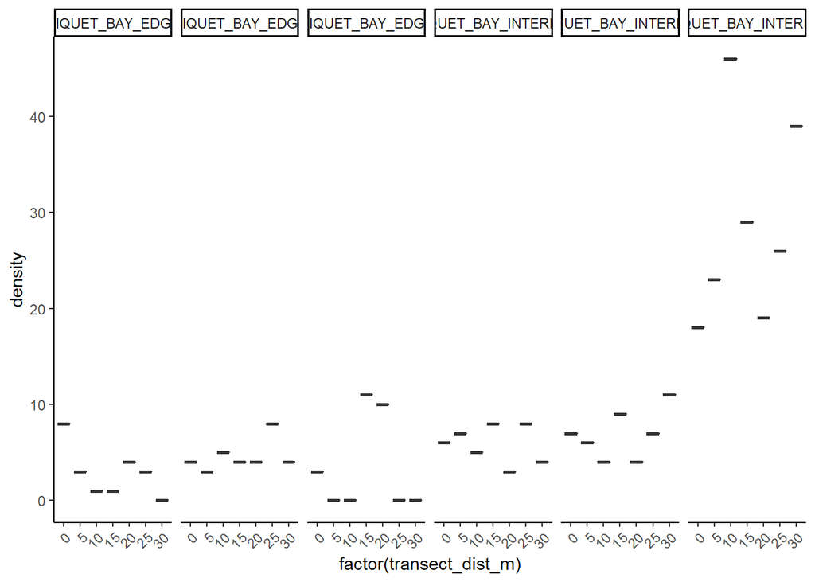

```r
zmDensity %>%
  filter(survey == "TRIQUET_BAY",  # enter the survey name, in quotes
         year(date) == 2022,  # enter year here, no quotes needed
         month(date) == 8) %>%  # enter month here, no quotes needed
  ggplot(aes(x   = factor(transect_dist_m),
             y   = density)) +  # enter variable of choice here,
  geom_boxplot(outlier.colour = "red") +
  facet_grid(~ site_id) +
  theme_classic() +
  theme(axis.text.x = element_text(angle = 45, hjust = 1))
```

**TO DO:**

- Once suspect values have been found, confirm value with hard copy datasheets
- If values have been incorrectly entered, fix value in database
- Repeat as necessary, then re-download density data from the portal

#### Habitat surveys

Use ‘viewYearCounts’ function created for density data for viewing number of observations at all sites, in a year, by month; because these data are categorical (as opposed to the continuous density data), we will not check the range of values, but we can confirm the correct number of observations are present for each site visit.

Plot each year of data; check correct number of values are present

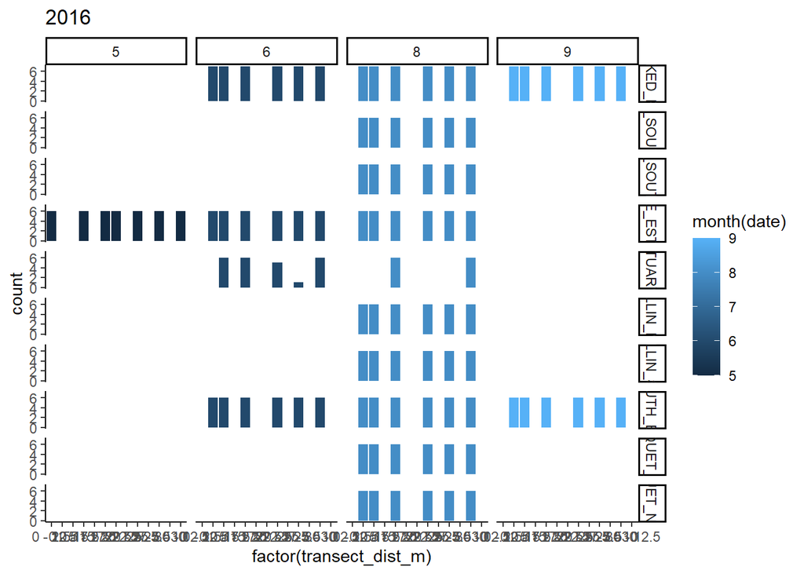

```r
viewYearCounts(zmHabitat, "2016")
```

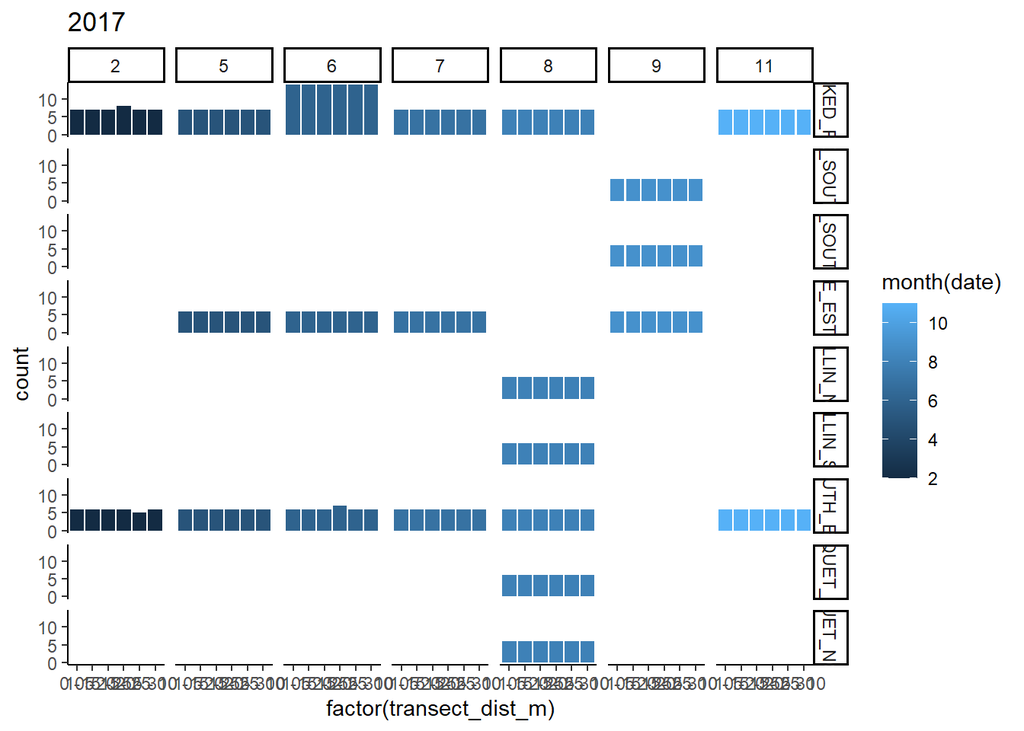

```r
viewYearCounts(zmHabitat, "2017")
```

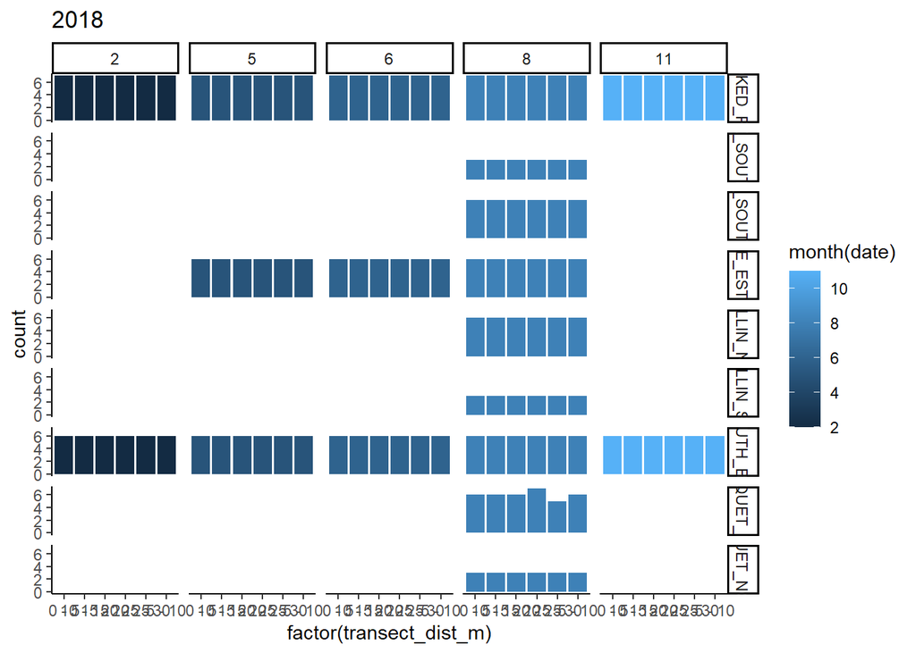

```r
viewYearCounts(zmHabitat, "2018")
```

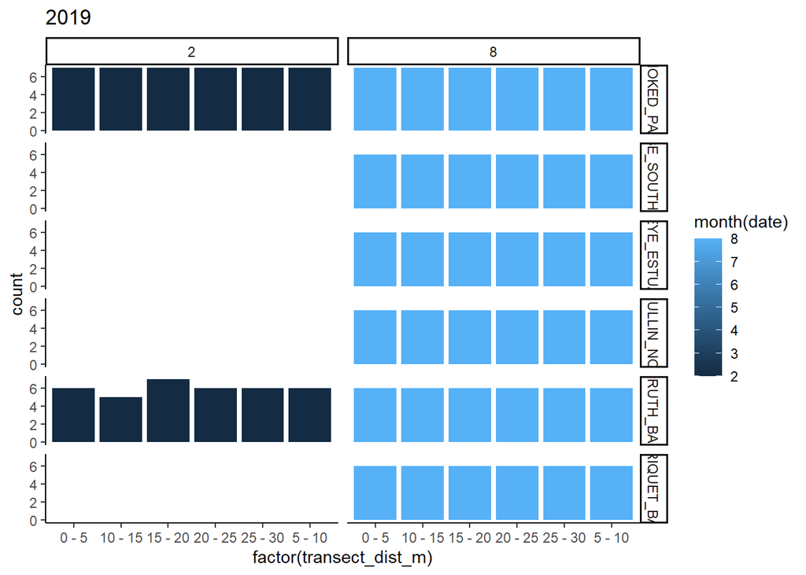

```r
viewYearCounts(zmHabitat, "2019")
```

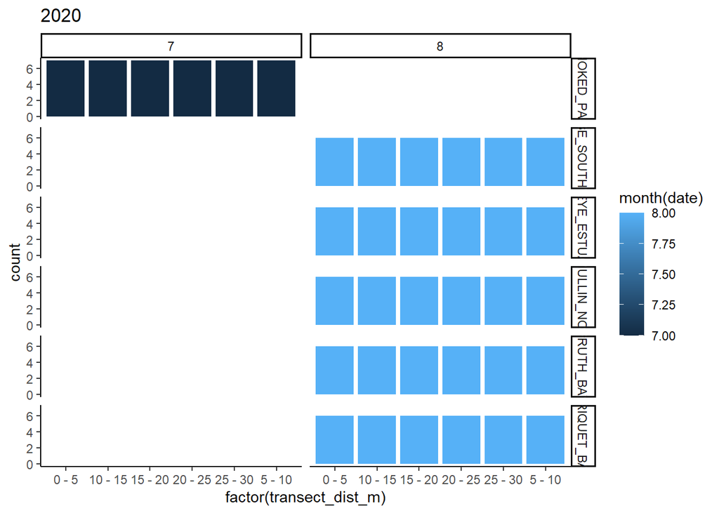

```r
viewYearCounts(zmHabitat, "2020")
```

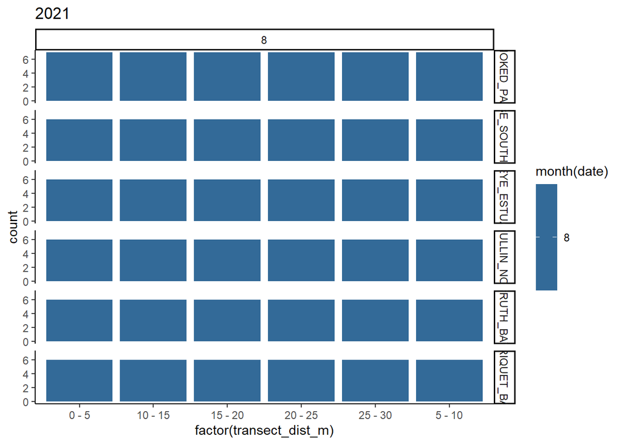

```r
viewYearCounts(zmHabitat, "2021")
```

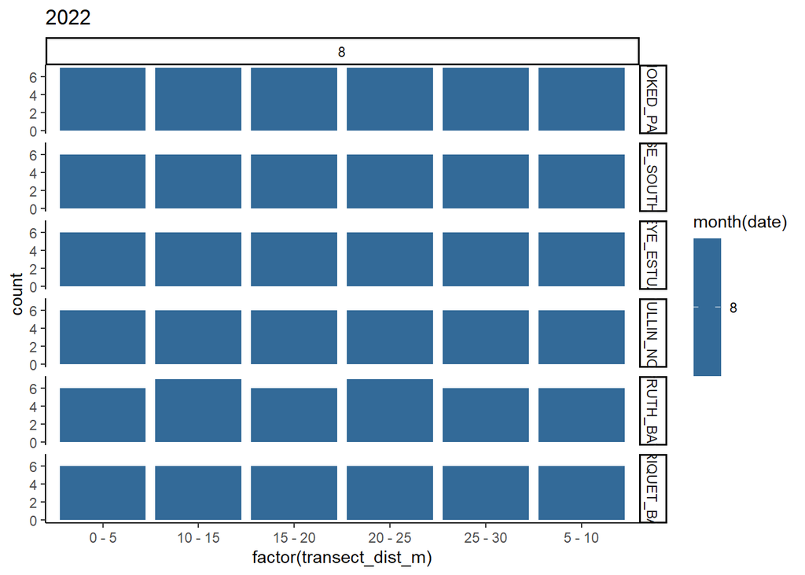

```r
viewYearCounts(zmHabitat, "2022")
```

**TO DO:**

- Once suspect values have been found, confirm value with hard copy datasheets
- Correct any errors in database, then re-download habitat data from the portal

##### Suspect values checked

- 2020 FM
- 2021 FM
- 2022 FM

#### Fix and QC depths

2016 depths are in feet, so convert to metres

```r
zmDensity <- zmDensity %>%
    mutate(depth = if_else(year(date) == 2016, depth * 0.3048, depth))
```

Flag depths >10m; these should all be entering errors (missing decimal point); check raw data sheets for exceptions if needed

```r
zmDensity %>%
  filter(depth >= 10)
```

```
##   organization work_area   project          survey                   site_id
## 1        HAKAI   CALVERT MARINEGEO GOOSE_SOUTHWEST     GOOSE_SOUTHWEST_EDGE2
## 2        HAKAI   CALVERT MARINEGEO       PRUTH_BAY           PRUTH_BAY_EDGE2
## 3        HAKAI   CALVERT MARINEGEO   KOEYE_ESTUARY   KOEYE_ESTUARY_INTERIOR6
## 4        HAKAI   CALVERT MARINEGEO GOOSE_SOUTHWEST GOOSE_SOUTHWEST_INTERIOR6
## 5        HAKAI   CALVERT MARINEGEO       PRUTH_BAY           PRUTH_BAY_EDGE3
## 6        HAKAI   CALVERT MARINEGEO   KOEYE_ESTUARY   KOEYE_ESTUARY_INTERIOR5
## 7        HAKAI   CALVERT MARINEGEO     TRIQUET_BAY         TRIQUET_BAY_EDGE2
##         date sampling_bout         dive_supervisor surveyor
## 1 2016-08-27             2                    Zach    Derek
## 2 2017-05-19             2 angeleen,angeleen.olson
## 3 2017-05-21             6        angeleen,gillian    derek
## 4 2018-08-08             6        angeleen,krystal    derek
## 5 2019-08-05             3         carolyn,krystal    derek
## 6 2019-08-16             5                angeleen    derek
```

[output cut: 25 more lines]

Correct those depths

```r
zmDensity <- zmDensity %>%
    mutate(depth = if_else(depth >= 10, depth * 0.1, depth))
```

#### Replace blank cells with NA

```r
zmDensity <- zmDensity %>% mutate_all(na_if,"")
zmHabitat <- zmHabitat %>% mutate_all(na_if,"")
```

#### Fix collector and tender names

**NOTE:** New divers, tenders, or tender combos may require the list of accepted names to be updated.

Import acceptable names

```r
# acceptable diver names
diversnames_accepted <- names$divers %>% data.frame
colnames(diversnames_accepted) <- "name"

# acceptable tender names
tendersnames_accepted <- names$tenders %>% data.frame
colnames(tendersnames_accepted) <- "name"
```

Density dataset

```r
# fix diver names
density_diversnames_data <- unique(zmDensity$surveyor) %>% sort %>% data.frame
colnames(density_diversnames_data) <- "name"
density_diversnames_tofix <- anti_join(density_diversnames_data, diversnames_accepted)
density_diversnames_tofix$replace <- c("andrew", "derek", "derek", "kyle", "ondine", "ondine", "other", "zach")
zmDensity <- FindReplace(zmDensity, "surveyor", density_diversnames_tofix, from = "name", to = "replace", exact = TRUE, vector = FALSE)
```

```
## Only exact matches will be replaced.
```

```r
# fix tender names
density_tendersnames_data <- unique(zmDensity$dive_supervisor) %>% sort %>% data.frame
colnames(density_tendersnames_data) <- "name"
density_tendersnames_tofix <- anti_join(density_tendersnames_data, tendersnames_accepted)
density_tendersnames_tofix$replace <- c("angeleen", "angeleen,carolyn,krystal", "derek", "gillian", "gillian", "kyle", "ondine", "other,zach", "zach")
zmDensity <- FindReplace(zmDensity, "dive_supervisor", density_tendersnames_tofix, from = "name", to = "replace", exact = TRUE, vector = FALSE)
```

```
## Only exact matches will be replaced.
```

Habitat dataset

```r
# fix diver names
habitat_diversnames_data <- unique(zmHabitat$surveyor) %>% sort %>% data.frame
colnames(habitat_diversnames_data) <- "name"
habitat_diversnames_tofix <- anti_join(habitat_diversnames_data, diversnames_accepted)
habitat_diversnames_tofix$replace <- c("andrew", "derek", "kyle", "ondine", "other", "zach")
zmHabitat <- FindReplace(zmHabitat, "surveyor", habitat_diversnames_tofix, from = "name", to = "replace", exact = TRUE, vector = FALSE)
```

```
## Only exact matches will be replaced.
```

```r
# fix tender names
habitat_tendersnames_data <- unique(zmHabitat$dive_supervisor) %>% sort %>% data.frame
colnames(habitat_tendersnames_data) <- "name"
habitat_tendersnames_tofix <- anti_join(habitat_tendersnames_data, tendersnames_accepted)
habitat_tendersnames_tofix$replace <- c("angeleen", "angeleen,carolyn,krystal", "derek", "gillian", "gillian", "kyle", "ondine", "other,zach", "zach")
zmHabitat <- FindReplace(zmHabitat, "dive_supervisor", habitat_tendersnames_tofix, from = "name", to = "replace", exact = TRUE, vector = FALSE)
```

```
## Only exact matches will be replaced.
```

#### Join site metadata

Tidy up column and site names

```r
sites <- rename_with(sites, tolower)
colnames(sites) <- gsub("\\.", "_", colnames(sites))
sites <- subset(sites, project_name == "Seagrass" & gps_level == "transect")

sites$site_name <- toupper(sites$site_name)
sites$site_name <- gsub(" ", "_", sites$site_name)
sites$site_name <- gsub("\\.", "_", sites$site_name)
sites$site_name <- gsub("GOOSE_SE", "GOOSE_SOUTHEAST", sites$site_name)
sites$site_name <- gsub("GOOSE_SW", "GOOSE_SOUTHWEST", sites$site_name)

sites$point_name <- gsub(".*_", "", sites$point_name)
sites$point_name <- gsub("E", "EDGE", sites$point_name)
sites$point_name <- gsub("I", "INTERIOR", sites$point_name)
sites$point_name <- paste(sites$site_name, sites$point_name, sep = "_")
```

Join site metadata onto data sets

```r
zmDensity <- left_join(zmDensity, (select(sites, "point_name", "substrate", "decimal_lat", "decimal_long", "end_transect_decimal_lat", "end_transect_decimal_lon")), by = c("site_id" = "point_name"))

zmHabitat <- left_join(zmHabitat, (select(sites, "point_name", "decimal_lat", "decimal_long", "end_transect_decimal_lat", "end_transect_decimal_lon")), by = c("site_id" = "point_name"))
```

### Save finished data sets

```r
write.csv(zmDensity, "./output/seagrass_density_survey.csv")
write.csv(zmHabitat,"./output/seagrass_habitat_survey.csv")
```